# Lab-5

eagbozo@urfu.ru

## Static and Interactive Maps (tmap)

```r
library(sf)
library(raster)
library(tidyverse)
library(spData)
```

```r
library(spDataLarge)

library(tmap)    # for static and interactive maps
library(mapview) # for interactive maps
```

We will be using the **World**/**world** datasets available from the spData package

```r
World=data("World")
view(World)
```

Plot the sf (shapefile) of Russia

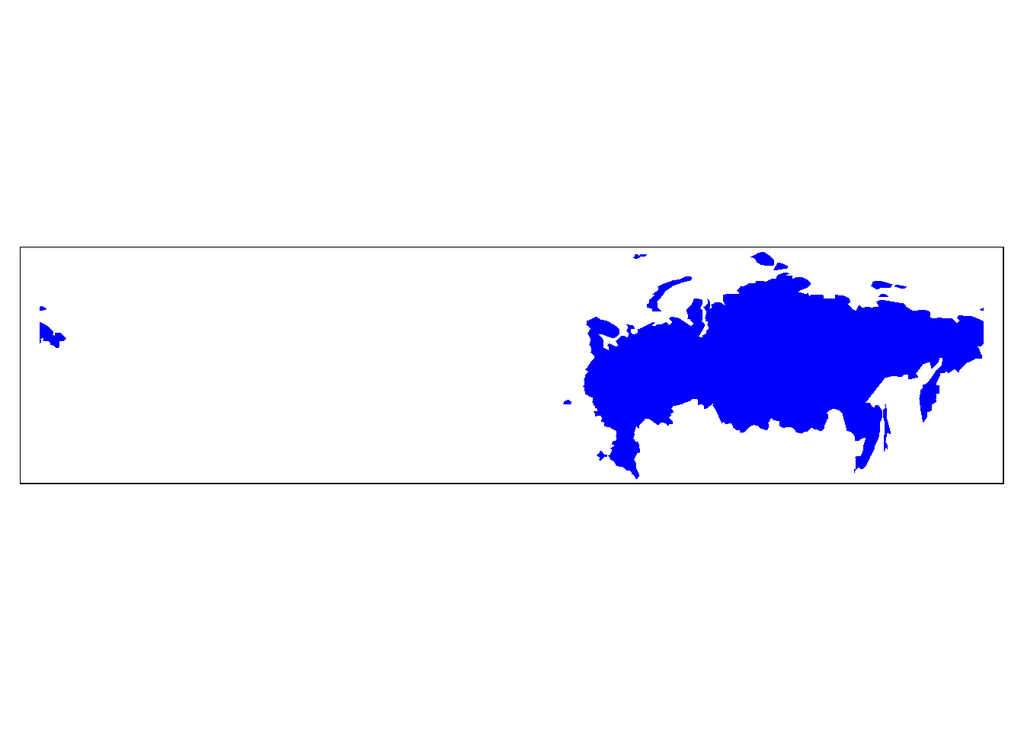

```r
russia = world %>% dplyr::filter(name_long=="Russian Federation")

#shapefiles
tm_shape(russia) +
  tm_fill(col="blue")
```

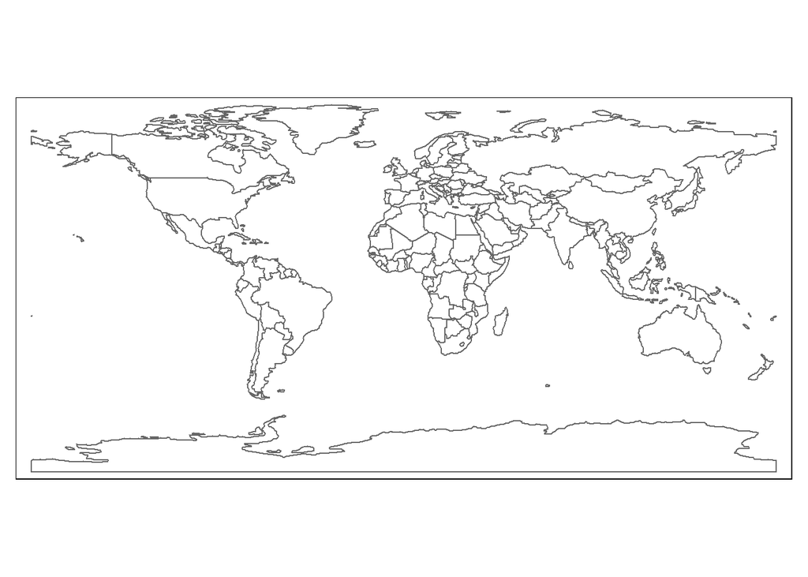

```r
tm_shape(world) +
  tm_borders()
```

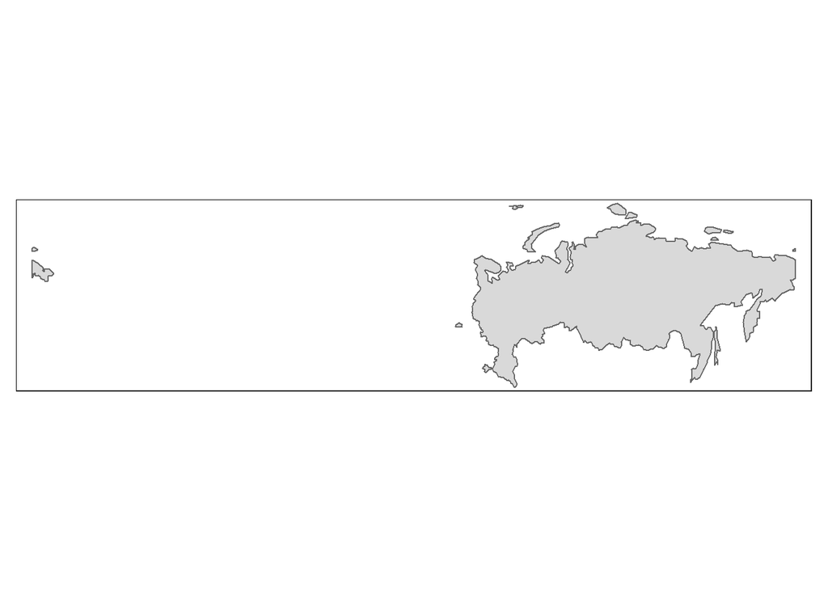

```r
tm_shape(russia) +
  tm_borders() +
  tm_fill()
```

we can also include scales to our plot

```r
tm_shape(russia) + tm_borders() + tm_fill()  + tm_scale_bar(position=c("left", "bottom"))
```

```
## Scale bar set for latitude km and will be different at the top and bottom of the map.
```

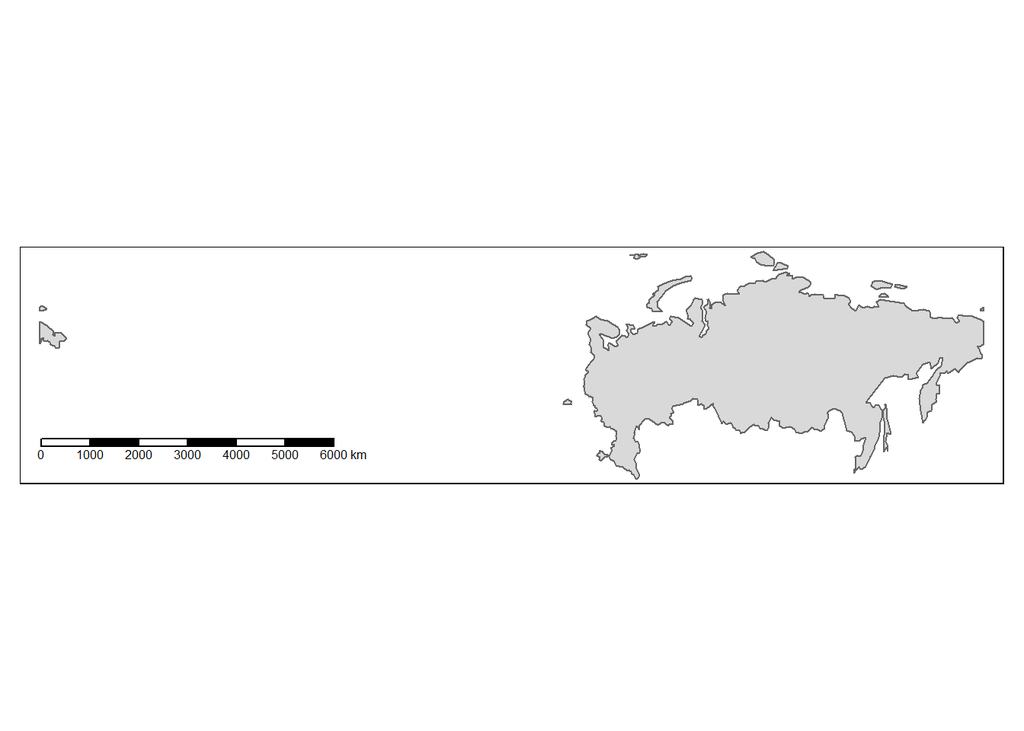

##### Note: **qtm()** is another mapping function but difficult to control it’s layers.

Let’s explore the **New Zealand** dataset also available in the package.

```r
nz #new zealand
```

```
## Simple feature collection with 16 features and 6 fields
## geometry type:  MULTIPOLYGON
## dimension:      XY
## bbox:           xmin: 1090144 ymin: 4748537 xmax: 2089533 ymax: 6191874
## epsg (SRID):    2193
## proj4string:    +proj=tmerc +lat_0=0 +lon_0=173 +k=0.9996 +x_0=1600000 +y_0=10000000 +ellps=GRS80 +towgs84=0,0,0,0,0,0,0 +units=m +no_defs
## First 10 features:
##                 Name Island Land_area Population Median_income Sex_ratio
## 1          Northland  North 12500.561     175500         23400 0.9424532
## 2           Auckland  North  4941.573    1657200         29600 0.9442858
## 3            Waikato  North 23900.036     460100         27900 0.9520500
## 4      Bay of Plenty  North 12071.145     299900         26200 0.9280391
## 5           Gisborne  North  8385.827      48500         24400 0.9349734
## 6        Hawke's Bay  North 14137.524     164000         26100 0.9238375
## 7           Taranaki  North  7254.480     118000         29100 0.9569363
## 8  Manawatu-Wanganui  North 22220.608     234500         25000 0.9387734
## 9         Wellington  North  8048.553     513900         32700 0.9335524
## 10        West Coast  South 23245.456      32400         26900 1.0139072
##                              geom
## 1  MULTIPOLYGON (((1745493 600...
## 2  MULTIPOLYGON (((1803822 590...
## 3  MULTIPOLYGON (((1860345 585...
## 4  MULTIPOLYGON (((2049387 583...
## 5  MULTIPOLYGON (((2024489 567...
## 6  MULTIPOLYGON (((2024489 567...
## 7  MULTIPOLYGON (((1740438 571...
## 8  MULTIPOLYGON (((1866732 566...
## 9  MULTIPOLYGON (((1881590 548...
## 10 MULTIPOLYGON (((1557042 531...
```

```r
map_nz = tm_shape(nz) + tm_polygons()
class(map_nz)
```

```
## [1] "tmap"
```

view the map of new zealand —- tm_polygons() adds the other islands that make up the state - more like stiches all together

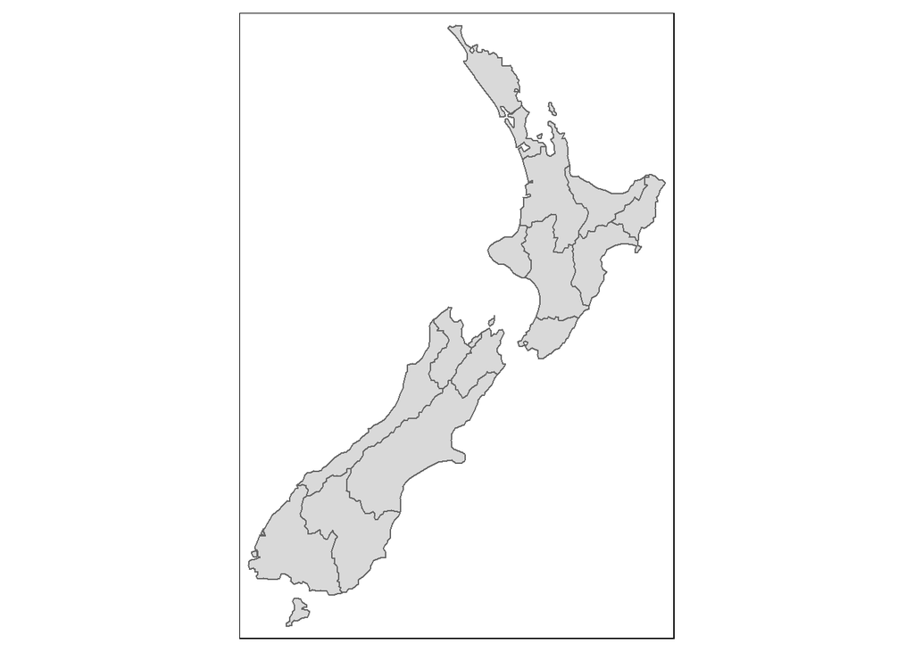

```r
map_nz
```

```r
nz_elev
```

```
## class      : RasterLayer
## dimensions : 1450, 1115, 1616750  (nrow, ncol, ncell)
## resolution : 1000, 1000  (x, y)
## extent     : 995456.5, 2110457, 4741961, 6191961  (xmin, xmax, ymin, ymax)
## crs        : +proj=tmerc +lat_0=0 +lon_0=173 +k=0.9996 +x_0=1600000 +y_0=10000000 +ellps=GRS80 +towgs84=0,0,0,0,0,0,0 +units=m +no_defs
## source     : memory
## names      : elevation
## values     : 0, 4140.333  (min, max)
```

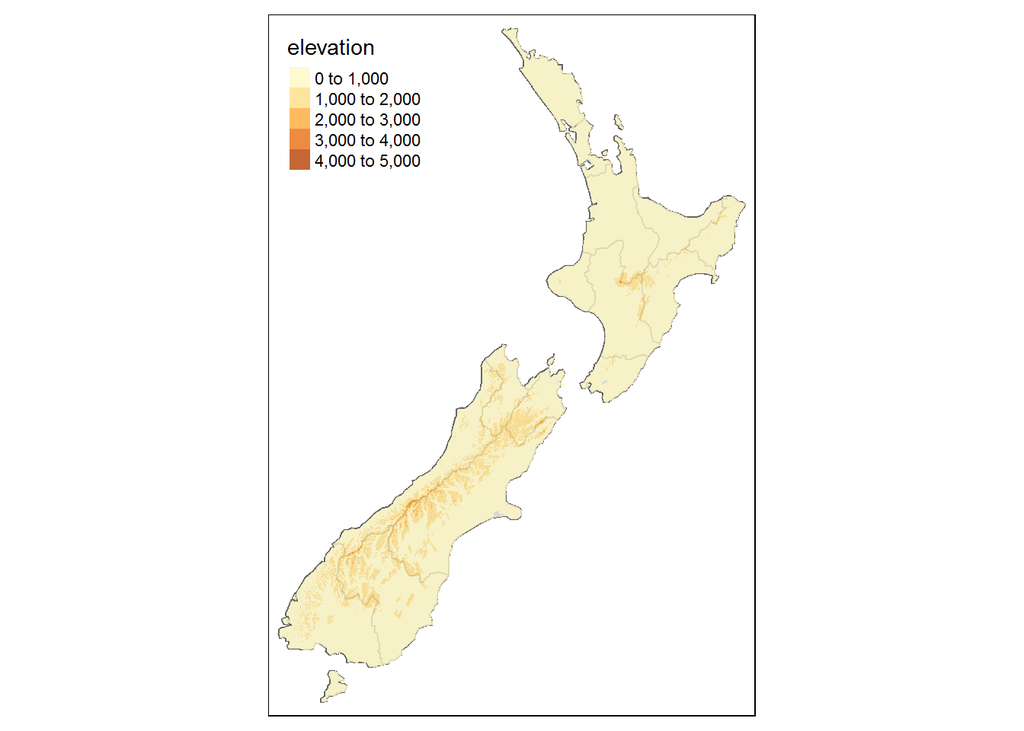

```r
#plot the elevated
map_nz1 = map_nz +
  tm_shape(nz_elev) + tm_raster(alpha = 0.8)

map_nz1
```

as many layers or shapes as possible can be added to tmap objects. **st_buffer** computes a buffer around this geometry/each geometry **st_union** Combines several feature geometries into one, without unioning or resolving internal boundaries **st_cast** - Casts/Converts one geometry to another type: either simplify, or cast explicitly we can convert to **MULTIPOLYGON, POINT, LINESTRING**, etc.

we indicate New Zealand’s Territorial Waters by creating a layer as defined by the 1982 United Nations Convention on the Law of the Sea,[1] is a belt of coastal waters extending at 12 nautical miles (22.2 km) source: https://en.wikipedia.org/wiki/Territorial_waters

```r
nz_water = st_union(nz) %>% st_buffer(22200) %>%
  st_cast(to = "LINESTRING")
```

merge the Territorial waters layer with the Original NZ map

```r
map_nz2 = map_nz1 +
  tm_shape(nz_water) + tm_lines()

#view
```

add **nz_height** layer

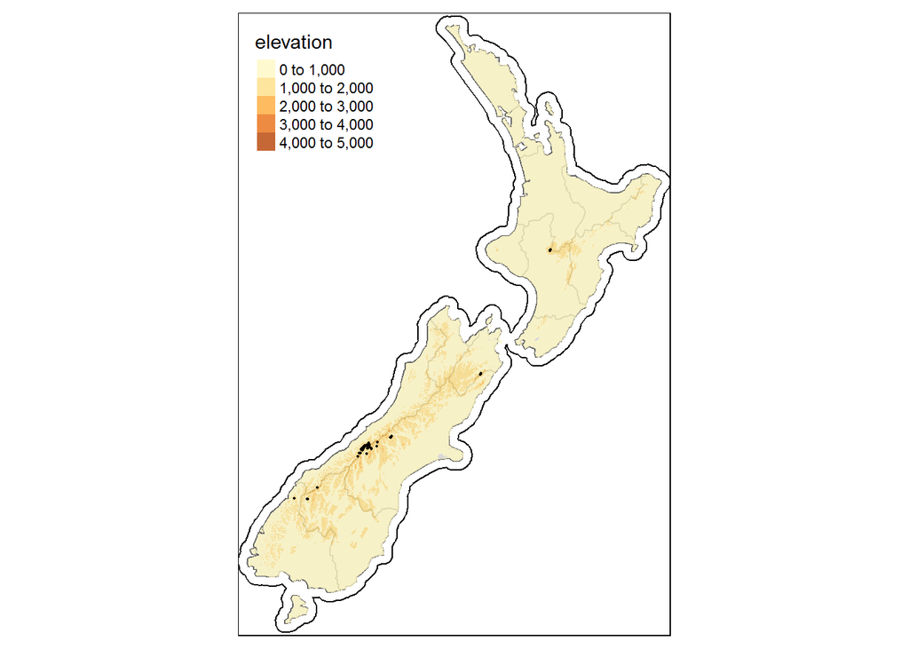

```r
map_nz3 = map_nz2 +
  tm_shape(nz_height) + tm_dots()

#view
map_nz3
```

Plot all our created maps previously **tmap_arrange()**

```
## Some legend labels were too wide. These labels have been resized to 0.55, 0.55, 0.55, 0.55. Increase legend.width (argument of tm_layout) to make the legend wider and therefore the labels larger.
## Some legend labels were too wide. These labels have been resized to 0.55, 0.55, 0.55, 0.55. Increase legend.width (argument of tm_layout) to make the legend wider and therefore the labels larger.
## Some legend labels were too wide. These labels have been resized to 0.55, 0.55, 0.55, 0.55. Increase legend.width (argument of tm_layout) to make the legend wider and therefore the labels larger.
```

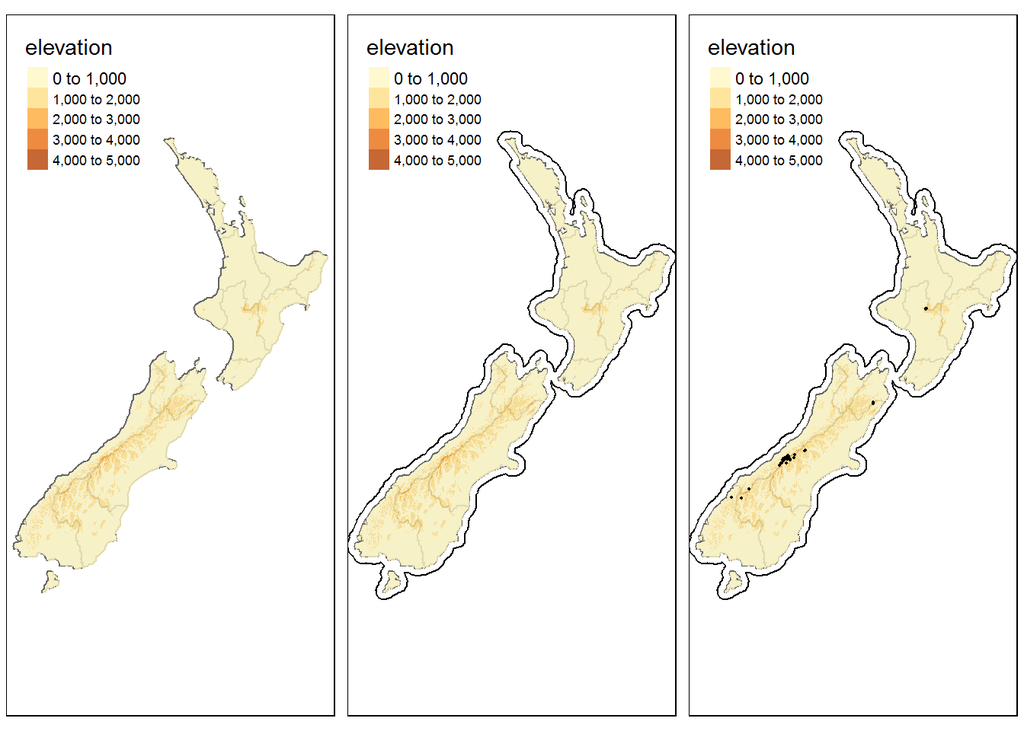

```r
tmap_arrange(map_nz1, map_nz2, map_nz3)
```

to understand how **T_MAP** works, use this code - *tmap_tip()* - to get new tips/examples

```r
#interactive mode view / plot
tmap_mode("plot")
```

```
## tmap mode set to plotting
```

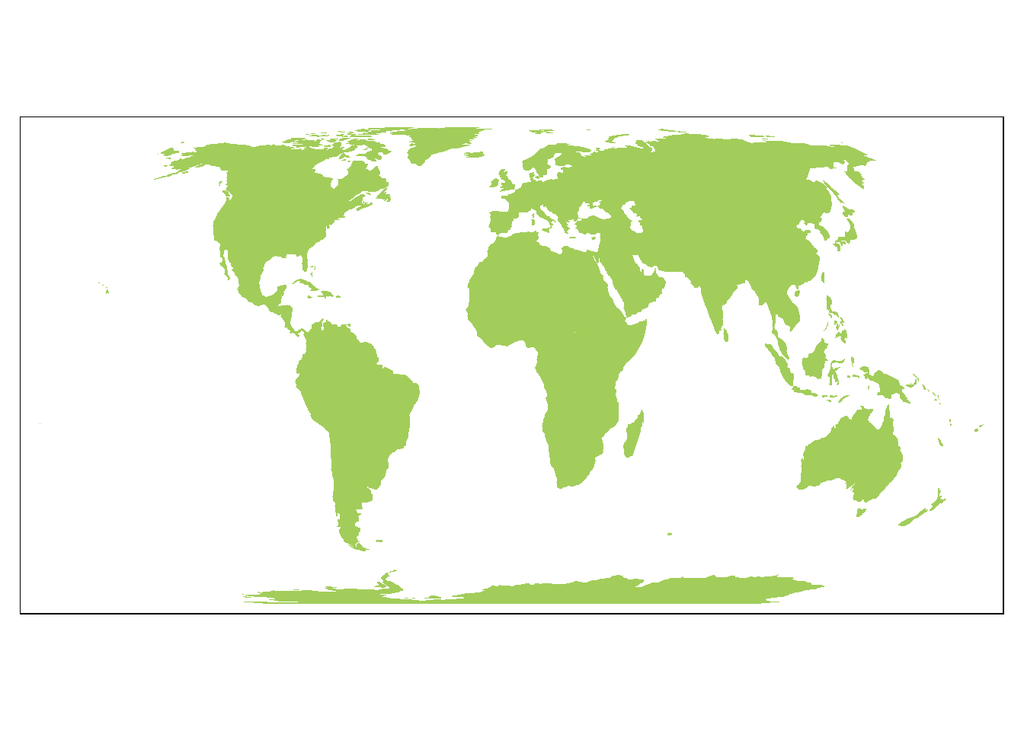

```r
#let call these 3 datasets
data(World, metro, rivers)

tm_shape(World) +
  tm_fill("darkolivegreen3")
```

We will then plot two facets of the world maps - Happy Planet Index & Economy

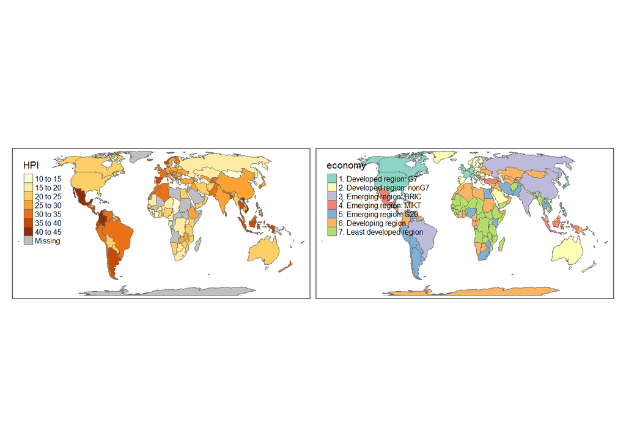

```r
tm_shape(World) +
  tm_polygons(c("HPI", "economy")) +
  tm_facets(sync = TRUE, ncol = 2)
```

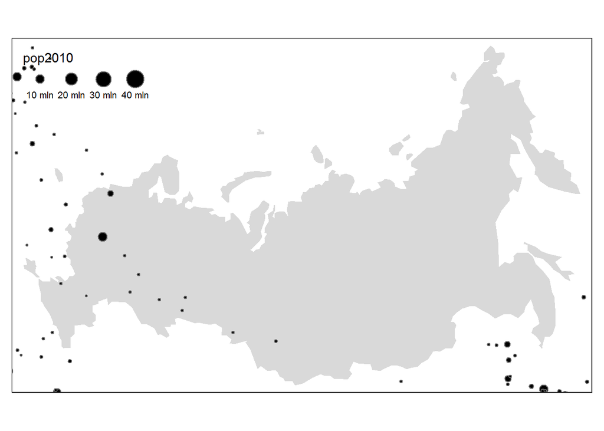

```r
tm_shape(russia, projection=3576) + tm_fill()+ tm_shape(metro) + tm_bubbles("pop2010", col = "black")
```

### Coordinate Reference Systems (CRS) - Projections

If a projection is not explicitly defined in the first call to **tm_shape**, then the output map will default to the first layer’s reference system. *crs values* -> 4326 … 3857 … **+proj=robin** …. **+proj=longlat** there are 3 main types (Source: Geocomputation with R)

to view the different projection attributes

```r
crs_data = rgdal::make_EPSG()
View(crs_data)
```

select the best projection attribute

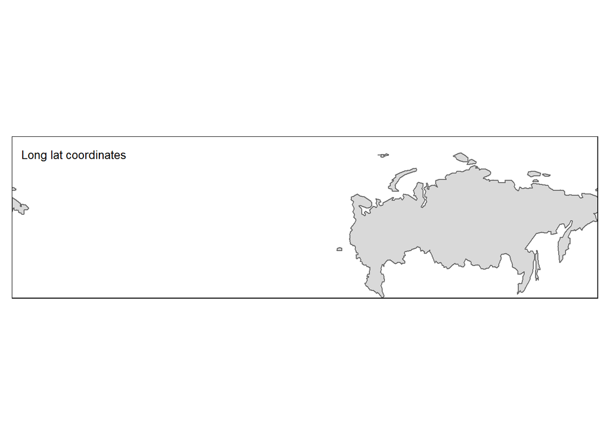

```r
tm_shape(World[136,], projection=4326) +
  tm_polygons() +
  tm_layout("Long lat coordinates", inner.margins=c(0,0,.1,0), title.size=.8)
```

we can also use dplyr to query one particular country or the traditional method ( country: *Russia* projection: *+proj=stere +lat_0=90 +lat_ts=90 +lon_0=105 +k=0.994 +x_0=2000000 +y_0=2000000 +datum=WGS84 +units=m +no_defs*

```r
map_ru = tm_shape(World[World$name=="Russia", ], projection = "+proj=stere +lat_0=90 +lat_ts=90 +lon_0=105 +k=0.994 +x_0=2000000 +y_0=2000000 +datum=WGS84 +units=m +no_defs
") +
  tm_polygons()
```

add another layer to the previous map

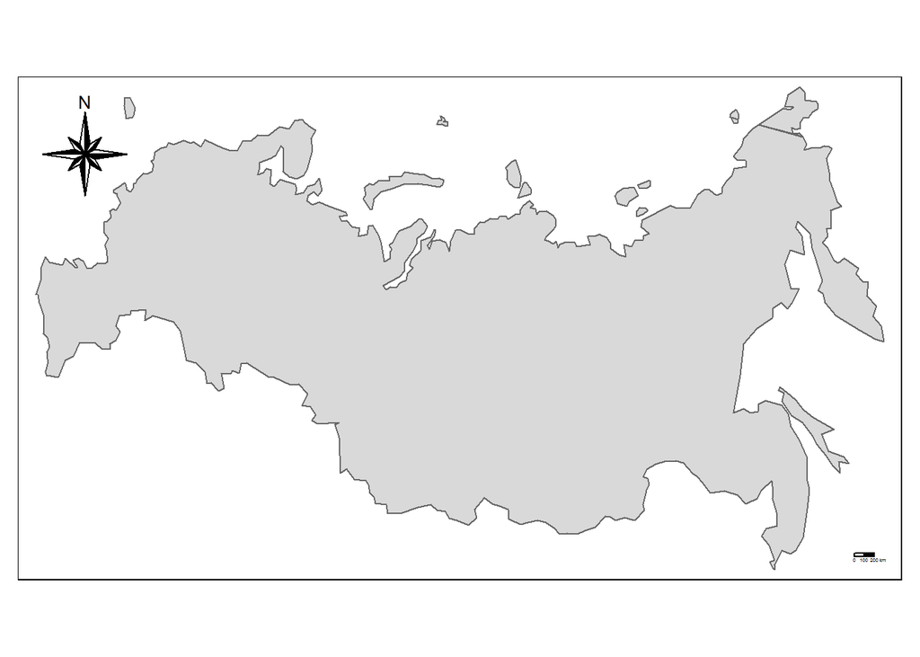

```r
map_ru +
  tm_compass(type = "8star", position = c("left", "top")) +
  tm_scale_bar(breaks = c(0, 100, 200), text.size = 1)
```

we can also switch the map mode to **view**

```r
tmap_mode("view")
```

```
## tmap mode set to interactive viewing
```

```r
map_ru + tm_basemap(server="OpenStreetMap",alpha=0.5)
```

[interactive chart not shown]

swtich back to plot mode

```r
tmap_mode("plot")
```

```
## tmap mode set to plotting
```

we can also plot various map styles

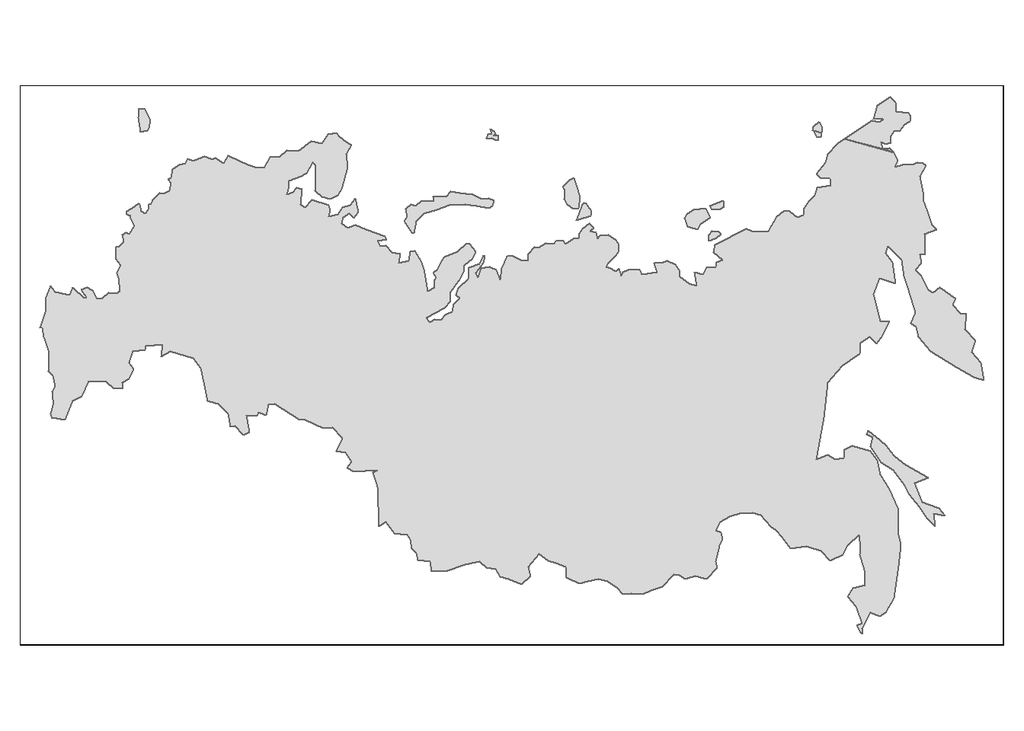

```r
map_ru + tm_style("bw")
```

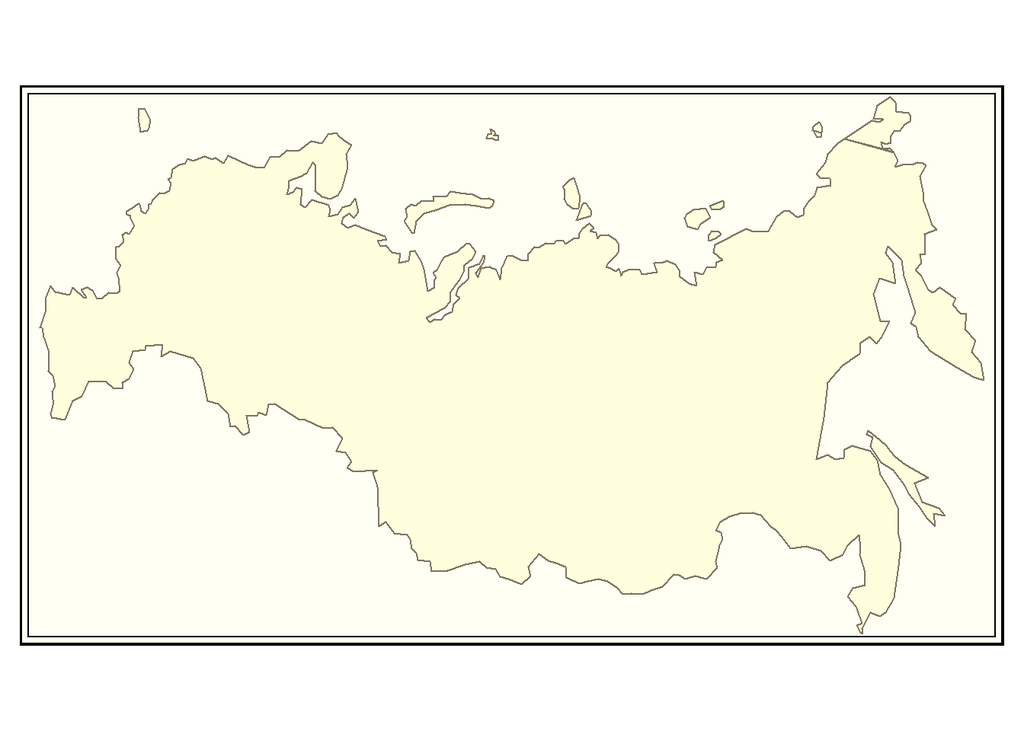

```r
map_ru + tm_style("classic")
```

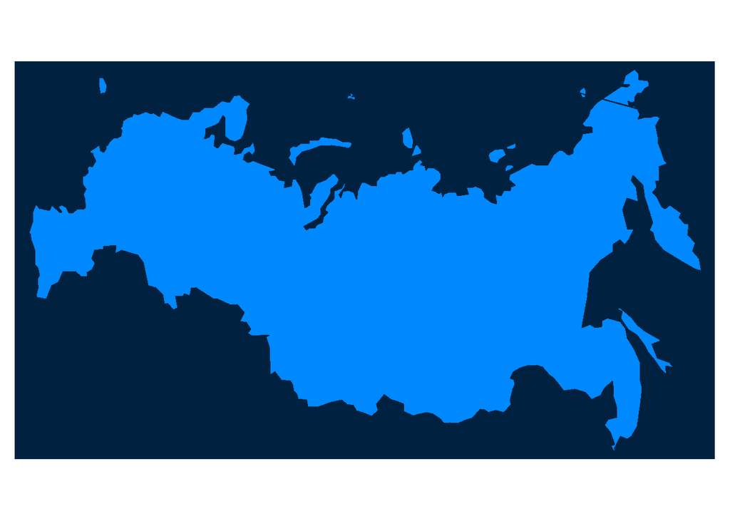

```r
map_ru + tm_style("cobalt")
```

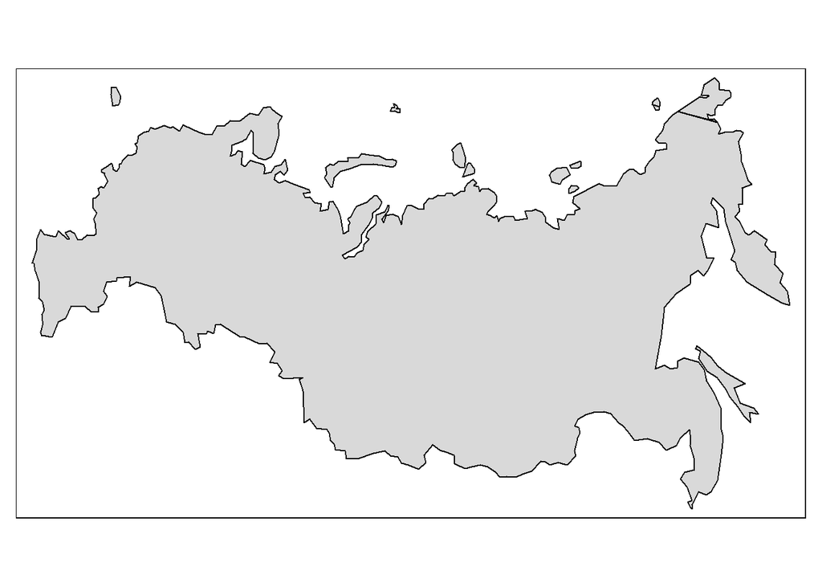

```r
map_ru + tm_style("col_blind")
```

working with the russian map, let’s add the **metro** dataset and plot the projected population for 2020

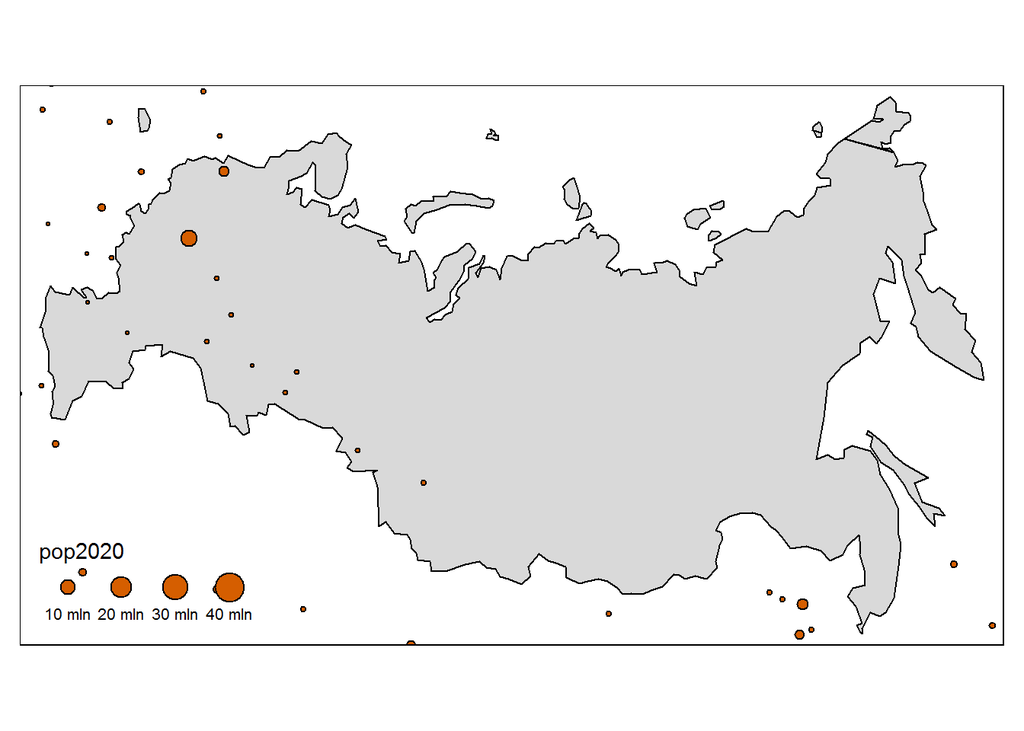

```r
map_ru + tm_style("col_blind") +
  tm_shape(metro) +
  tm_bubbles("pop2020")
```

### Bounding Box

we can also use the *bbox* parameter to focus on a particular country

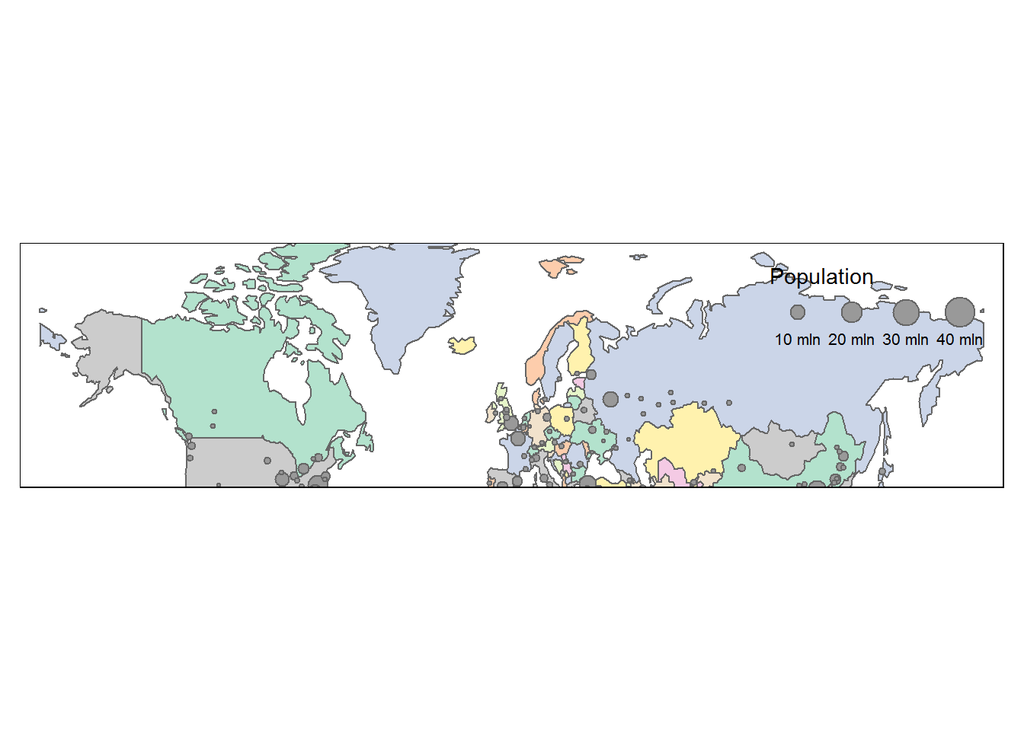

```r
tm_shape(World, bbox = "Russia", projection = 4326) +
  tm_polygons("MAP_COLORS", palette="Pastel2") +
  tm_shape(metro) +
  tm_bubbles("pop2010", title.size = "Population")
```

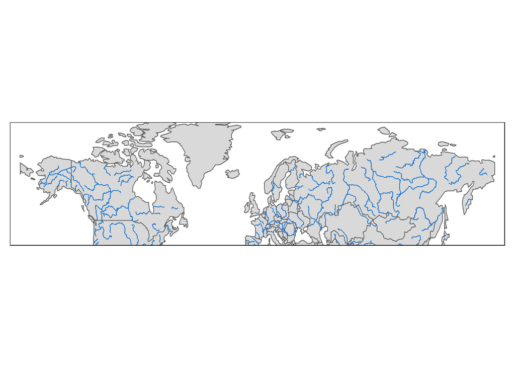

```r
tm_shape(World, bbox = "Russia", projection = "+proj=longlat") +
  tm_fill() +
  tm_borders()+
  tm_shape(rivers) +
  tm_lines(col="dodgerblue3")
```